[output not shown]

## Introduction

The essence of this paper is to explore the factors that determine students’ maths scores. A general research topic formulated from the dataset called PISA15. This paper is in two parts; firstly, we shall conduct the exploratory factor analysis to identify factors that explain learners’ performance. Secondly, I shall conduct a regression analysis based on the factor loadings of the EFA.

The paper starts with a brief background of the study; research questions and hypotheses; information about variables, statistical methods, and justification; results presentation as well as interpretation, and thereafter a discussion of the findings.

## Background

Previous scholars have identifed factors that affects learners academic achievement. A study on the influence of students’ attitudes on reading achievement by Martinez, Aricak, and Jewel (2008) demonstrated that there is a relationship between reading attitudes and reading achievement through the path model testing relations. Besides that, so many studies have been conducted in the past that have demonstrated the relationship between reading attitudes and reading achievement. Dawkins (2013) also adds that most studies on reading achievement have used Bronfenbrenner’s theory on the study and understand how a home or school environments influence students reading achievement.

*Research questions*:

What are the predictors of maths achievement in Sweden?

what is the best model that explains mathematics scores among learners in Sweden?

## Methods

### Exploratory Factor Analysis

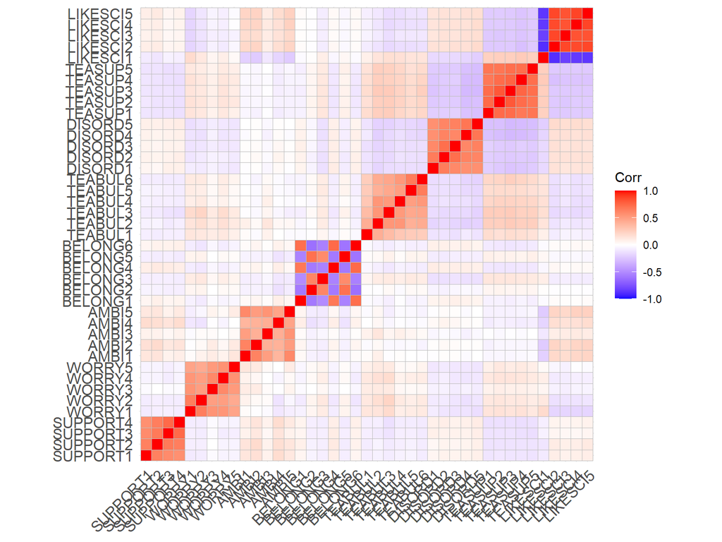

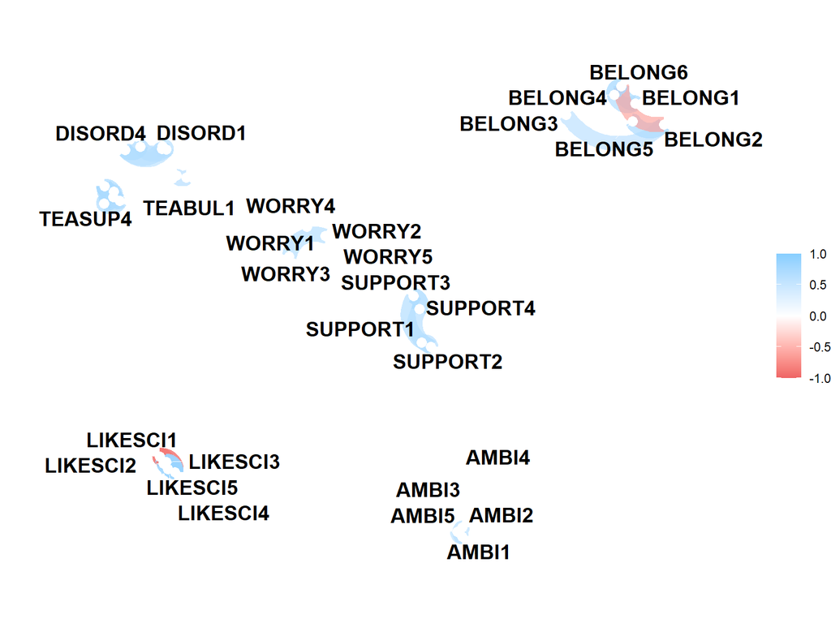

### Assumptions for Factorability

── Kaiser-Meyer-Olkin criterion (KMO) ──────────────────────────────────────────

✔ The overall KMO value for your data is meritorious. These data are probably suitable for factor analysis.

Overall: 0.897

For each variable: SUPPORT1 SUPPORT2 SUPPORT3 SUPPORT4 WORRY1 WORRY2 WORRY3 WORRY4 0.884 0.858 0.813 0.831 0.860 0.853 0.864 0.868 WORRY5 AMBI1 AMBI2 AMBI3 AMBI4 AMBI5 BELONG1 BELONG2 0.879 0.825 0.857 0.850 0.900 0.859 0.897 0.871 BELONG3 BELONG4 BELONG5 BELONG6 TEABUL1 TEABUL2 TEABUL3 TEABUL4 0.931 0.894 0.891 0.874 0.907 0.892 0.922 0.897 TEABUL5 TEABUL6 DISORD1 DISORD2 DISORD3 DISORD4 DISORD5 TEASUP1 0.841 0.846 0.926 0.879 0.896 0.908 0.907 0.944 TEASUP2 TEASUP3 TEASUP4 TEASUP5 LIKESCI1 LIKESCI2 LIKESCI3 LIKESCI4 0.915 0.912 0.940 0.942 0.937 0.910 0.940 0.929 LIKESCI5 0.924

$chisq [1] 102937

$p.value [1] 0

$df [1] 820

| Test | HZ | p value | MVN |
| --- | --- | --- | --- |
| Henze-Zirkler | 1.008115 | 0 | NO |

The score of less than 0.05 violates the assumption of multivariate skewness

```
Multivariate Normality Test Based on Skewness
```

we run the parallel test, VSS technique and Kaiser Gutman criterion to determine the number of factors to include in our model.Using these three criteria, it appeared that 8 or 10 factors would be sufficient for an optimal balance between comprehensiveness and parsimony. Since both Velicer MAP, VSS and Kaiser Gutman criterion suggest 8 factors, we shall created our model with 8 factors.

[figure not shown]

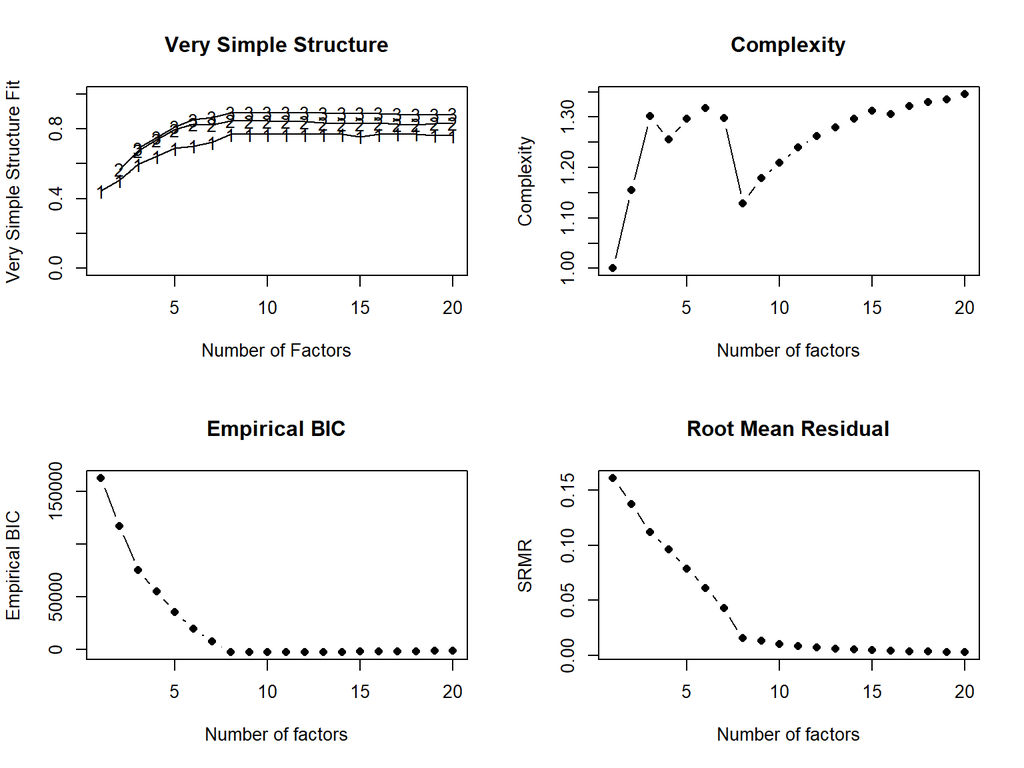

Number of factors Call: vss(x = x, n = n, rotate = rotate, diagonal = diagonal, fm = fm, n.obs = n.obs, plot = FALSE, title = title, use = use, cor = cor) VSS complexity 1 achieves a maximimum of Although the vss.max shows 18 factors, it is probably more reasonable to think about 8 factors VSS complexity 2 achieves a maximimum of 0.85 with 8 factors The Velicer MAP achieves a minimum of 0.01 with 8 factors Empirical BIC achieves a minimum of -3080.95 with 10 factors Sample Size adjusted BIC achieves a minimum of -741.35 with 18 factors

Statistics by number of factors vss1 vss2 map dof chisq prob sqresid fit RMSEA BIC SABIC complex 1 0.44 0.00 0.0422 779 80029 0.0e+00 71.7 0.44 0.160 73573 76048 1.0 2 0.51 0.57 0.0434 739 60315 0.0e+00 55.5 0.57 0.142 54190 56538 1.2 3 0.60 0.68 0.0365 700 47621 0.0e+00 40.2 0.69 0.130 41819 44044 1.3 4 0.64 0.74 0.0316 662 37805 0.0e+00 31.6 0.75 0.119 32318 34422 1.3 5 0.69 0.80 0.0295 625 29795 0.0e+00 23.3 0.82 0.108 24615 26601 1.3 6 0.70 0.83 0.0263 589 19387 0.0e+00 17.0 0.87 0.090 14505 16377 1.3 7 0.72 0.82 0.0191 554 11876 0.0e+00 11.6 0.91 0.072 7284 9044 1.3 8 0.77 0.85 0.0083 520 4272 0.0e+00 7.1 0.94 0.043 -38 1615 1.1 9 0.77 0.84 0.0095 487 3471 0.0e+00 6.5 0.95 0.039 -565 983 1.2 10 0.77 0.85 0.0106 455 2388 7.6e-259 6.2 0.95 0.033 -1383 62 1.2 11 0.77 0.84 0.0118 424 1904 6.3e-186 5.8 0.95 0.030 -1610 -263 1.2 12 0.77 0.84 0.0130 394 1589 6.2e-143 5.5 0.96 0.028 -1677 -425 1.3 13 0.77 0.83 0.0142 365 1242 5.0e-96 5.3 0.96 0.025 -1783 -623 1.3 14 0.77 0.83 0.0162 337 1032 1.6e-71 5.2 0.96 0.023 -1762 -691 1.3 15 0.76 0.83 0.0180 310 921 6.7e-62 5.0 0.96 0.022 -1648 -663 1.3 16 0.77 0.83 0.0203 284 854 2.3e-58 4.4 0.97 0.022 -1500 -598 1.3 17 0.77 0.83 0.0230 259 692 4.0e-41 4.3 0.97 0.020 -1455 -632 1.3 18 0.77 0.82 0.0258 235 460 1.1e-16 4.2 0.97 0.016 -1488 -741 1.3 19 0.76 0.83 0.0299 212 401 9.1e-14 3.9 0.97 0.015 -1356 -683 1.3 20 0.76 0.83 0.0361 190 357 2.7e-12 3.8 0.97 0.015 -1218 -614 1.3 eChisq SRMR eCRMS eBIC 1 169203 0.1611 0.1653 162746 2 123188 0.1374 0.1448 117063 3 81155 0.1115 0.1207 75353 4 60053 0.0960 0.1068 54566 5 40290 0.0786 0.0900 35110 6 24469 0.0613 0.0723 19587 7 11830 0.0426 0.0518 7239 8 1567 0.0155 0.0195 -2743 9 1084 0.0129 0.0167 -2953 10 690 0.0103 0.0138 -3081 11 468 0.0085 0.0118 -3047 12 327 0.0071 0.0102 -2939 13 232 0.0060 0.0089 -2793 14 176 0.0052 0.0081 -2617 15 144 0.0047 0.0076 -2425 16 112 0.0042 0.0071 -2241 17 88 0.0037 0.0065 -2059 18 71 0.0033 0.0062 -1876 19 55 0.0029 0.0057 -1702 20 42 0.0025 0.0053 -1532

Eigenvalues were found using EFA.

── Number of factors suggested by Kaiser-Guttmann criterion ────────────────────

◌ With EFA-determined eigenvalues: 8

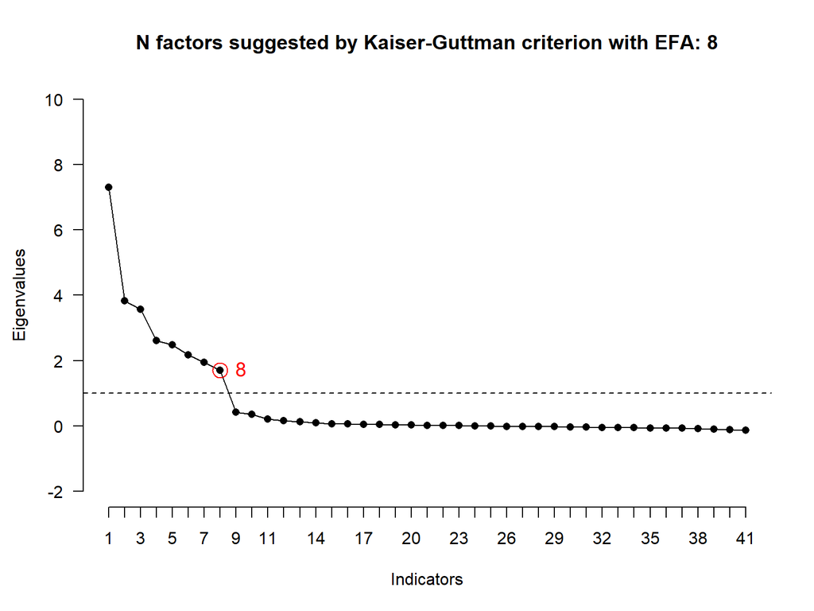

#### create the first model

variable **LIKESCI2** (I like reading about science topics) has a highest communality value of 90% with the lowest being 20% **TEABUL1**(teachers called me less often than they called other students)

|  | sort(mod1$communality, decreasing = TRUE) |
| --- | --- |
| LIKESCI2 | 0.90 |
| LIKESCI5 | 0.88 |
| LIKESCI1 | 0.85 |
| LIKESCI4 | 0.85 |
| TEASUP3 | 0.81 |
| LIKESCI3 | 0.81 |
| TEASUP2 | 0.77 |
| SUPPORT3 | 0.72 |
| TEASUP4 | 0.71 |
| BELONG6 | 0.71 |
| DISORD2 | 0.71 |
| TEASUP1 | 0.68 |
| SUPPORT4 | 0.67 |
| TEASUP5 | 0.67 |
| SUPPORT2 | 0.67 |
| DISORD3 | 0.67 |
| BELONG4 | 0.65 |
| BELONG2 | 0.64 |
| DISORD5 | 0.64 |
| AMBI1 | 0.62 |
| AMBI5 | 0.62 |
| DISORD4 | 0.62 |
| WORRY1 | 0.60 |
| BELONG1 | 0.60 |
| BELONG5 | 0.59 |
| WORRY4 | 0.57 |
| WORRY3 | 0.56 |
| DISORD1 | 0.55 |
| TEABUL4 | 0.54 |
| TEABUL6 | 0.53 |
| SUPPORT1 | 0.53 |
| WORRY2 | 0.52 |
| BELONG3 | 0.51 |
| TEABUL2 | 0.50 |
| TEABUL5 | 0.50 |
| AMBI2 | 0.50 |
| TEABUL3 | 0.49 |
| WORRY5 | 0.47 |
| AMBI3 | 0.46 |
| AMBI4 | 0.35 |
| TEABUL1 | 0.20 |

### Factor Rotation

we prefer oblique rotation due to their accuracy and to honor the reality that most variables are correlated to some extent (Bandalos & Boehm-Kaufman, 2009). Schmitt (2011), argues that “because oblique rotation methods generally produce accurate and comparable factor structures to orthogonal methods even when interfactor correlations are negligible, it is strongly recommend that researchers only use oblique rotation methods because they generally result in more realistic and more statistically sound factor structures” (p. 312).

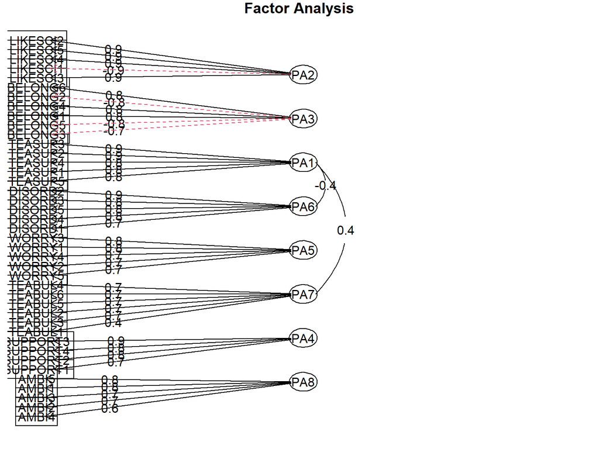

#### PROMAX ROTATION

Among the potential oblique analytic rotations, promax was chosen because it is an oblique modification of the widely accepted varimax procedure (Gorsuch, 1983; Thompson, 2004). I preferred using oblique rotation due to its accuracy and to honor the reality that most variables are correlated to some extent (Bandalos & Boehm-Kaufman, 2009). Schmitt (2011) argues that “because oblique rotation methods generally produce accurate and comparable factor structures to orthogonal methods even when interfactor correlations are negligible, it is strongly recommended that researchers only use oblique rotation methods because they generally result in more realistic and more statistically sound factor structures” (p. 312). Further, oblique rotation gives the same findings as Varimax in the case of uncorrelated data.

|  | sort(EFA_promax$communality, decreasing = TRUE) |
| --- | --- |
| LIKESCI2 | 0.90 |
| LIKESCI5 | 0.88 |
| LIKESCI1 | 0.85 |
| LIKESCI4 | 0.85 |
| TEASUP3 | 0.81 |
| LIKESCI3 | 0.81 |
| TEASUP2 | 0.77 |
| SUPPORT3 | 0.72 |
| TEASUP4 | 0.71 |
| BELONG6 | 0.71 |
| DISORD2 | 0.71 |
| TEASUP1 | 0.68 |
| SUPPORT4 | 0.67 |
| TEASUP5 | 0.67 |
| SUPPORT2 | 0.67 |
| DISORD3 | 0.67 |
| BELONG4 | 0.65 |
| BELONG2 | 0.64 |
| DISORD5 | 0.64 |
| AMBI1 | 0.62 |
| AMBI5 | 0.62 |
| DISORD4 | 0.62 |
| WORRY1 | 0.60 |
| BELONG1 | 0.60 |
| BELONG5 | 0.59 |
| WORRY4 | 0.57 |
| WORRY3 | 0.56 |
| DISORD1 | 0.55 |
| TEABUL4 | 0.54 |
| TEABUL6 | 0.53 |
| SUPPORT1 | 0.53 |
| WORRY2 | 0.52 |
| BELONG3 | 0.51 |
| TEABUL2 | 0.50 |
| TEABUL5 | 0.50 |
| AMBI2 | 0.50 |
| TEABUL3 | 0.49 |
| WORRY5 | 0.47 |
| AMBI3 | 0.46 |
| AMBI4 | 0.35 |
| TEABUL1 | 0.20 |

#### Factor Loadings

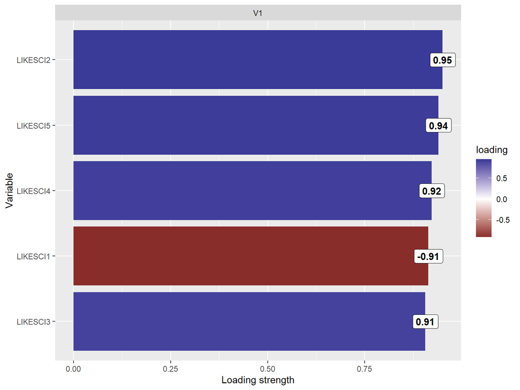

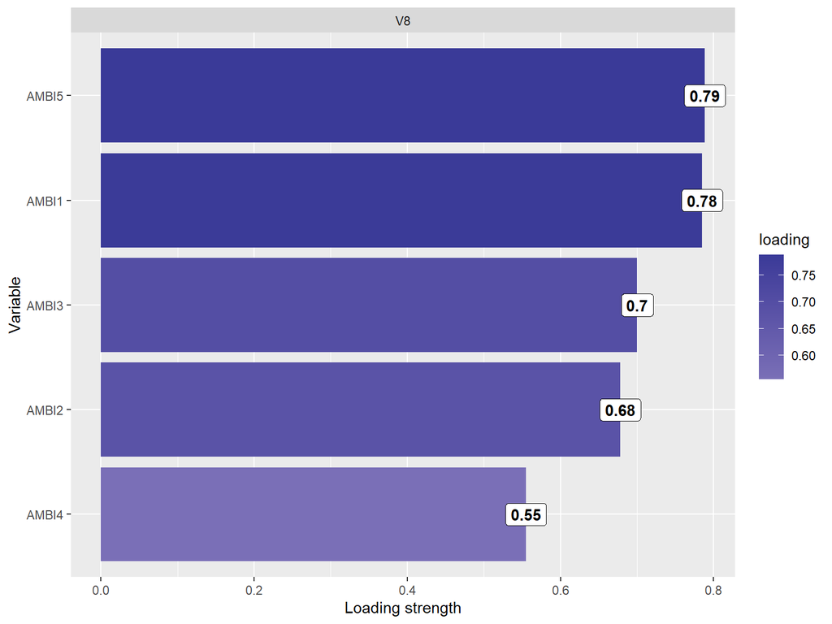

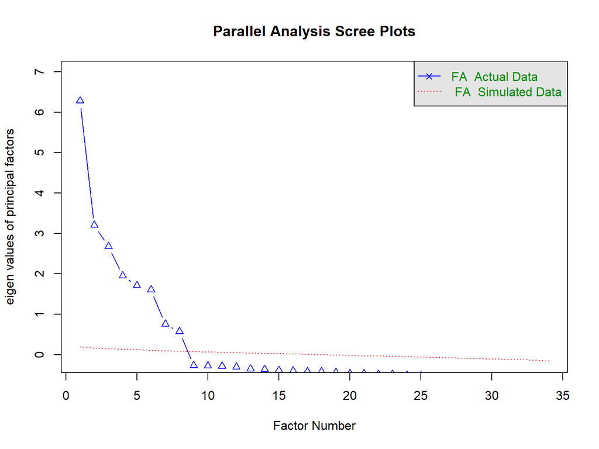

Parallel analysis suggests that the number of factors = 8 and the number of components = NA

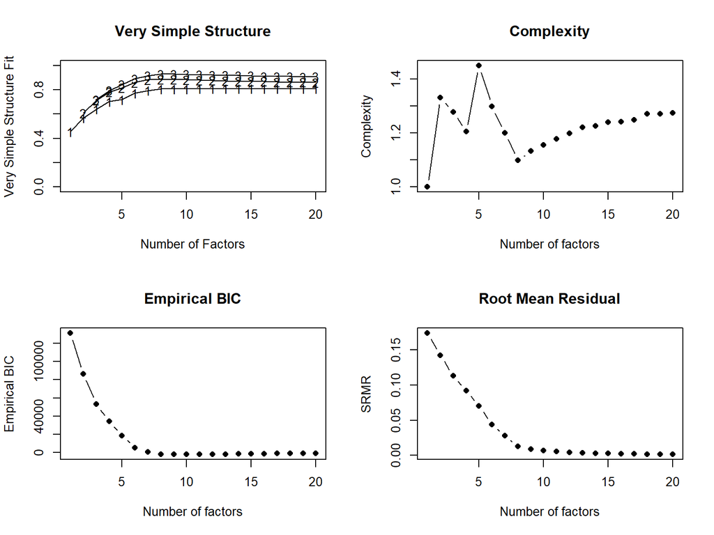

Number of factors Call: vss(x = x, n = n, rotate = rotate, diagonal = diagonal, fm = fm, n.obs = n.obs, plot = FALSE, title = title, use = use, cor = cor) VSS complexity 1 achieves a maximimum of Although the vss.max shows 20 factors, it is probably more reasonable to think about 14 factors VSS complexity 2 achieves a maximimum of 0.89 with 8 factors The Velicer MAP achieves a minimum of 0.01 with 7 factors Empirical BIC achieves a minimum of -2059.01 with 9 factors Sample Size adjusted BIC achieves a minimum of -637.78 with 14 factors

Statistics by number of factors vss1 vss2 map dof chisq prob sqresid fit RMSEA BIC SABIC complex 1 0.46 0.00 0.054 527 69657 0.0e+00 57.5 0.46 0.1816 65289 66963 1.0 2 0.57 0.61 0.055 494 54639 0.0e+00 41.3 0.61 0.1660 50545 52115 1.3 3 0.64 0.71 0.039 462 34647 0.0e+00 29.6 0.72 0.1364 30817 32285 1.3 4 0.70 0.78 0.033 431 26537 0.0e+00 21.6 0.80 0.1234 22965 24335 1.2 5 0.72 0.82 0.032 401 14440 0.0e+00 15.6 0.85 0.0938 11116 12390 1.5 6 0.77 0.86 0.017 372 8725 0.0e+00 9.3 0.91 0.0751 5642 6824 1.3 7 0.79 0.88 0.011 344 4789 0.0e+00 6.4 0.94 0.0570 1938 3031 1.2 8 0.81 0.89 0.012 317 2702 0.0e+00 4.3 0.96 0.0435 74 1082 1.1 9 0.81 0.89 0.013 291 1613 1.2e-181 3.9 0.96 0.0338 -799 125 1.1 10 0.81 0.88 0.015 266 1303 4.1e-136 3.7 0.97 0.0313 -902 -57 1.2 11 0.81 0.88 0.017 242 962 1.6e-86 3.5 0.97 0.0274 -1043 -274 1.2 12 0.81 0.88 0.020 219 740 8.5e-58 3.3 0.97 0.0245 -1075 -379 1.2 13 0.81 0.87 0.023 197 587 1.8e-40 3.2 0.97 0.0223 -1045 -419 1.2 14 0.81 0.87 0.027 176 262 2.9e-05 3.2 0.97 0.0111 -1197 -638 1.2 15 0.81 0.87 0.031 156 203 6.4e-03 3.2 0.97 0.0087 -1090 -594 1.2 16 0.81 0.87 0.037 137 148 2.5e-01 3.1 0.97 0.0044 -988 -552 1.2 17 0.81 0.86 0.045 119 127 2.8e-01 3.0 0.97 0.0042 -859 -481 1.2 18 0.81 0.86 0.049 102 94 7.1e-01 2.9 0.97 0.0000 -752 -428 1.3 19 0.81 0.86 0.057 86 74 8.2e-01 2.9 0.97 0.0000 -639 -366 1.3 20 0.81 0.86 0.072 71 57 8.9e-01 2.9 0.97 0.0000 -532 -306 1.3 eChisq SRMR eCRMS eBIC 1 1.4e+05 0.1743 0.1798 131205 2 9.0e+04 0.1424 0.1517 86348 3 5.7e+04 0.1131 0.1246 53243 4 3.8e+04 0.0921 0.1051 34286 5 2.2e+04 0.0704 0.0833 18783 6 8.6e+03 0.0439 0.0539 5515 7 3.4e+03 0.0277 0.0354 578 8 7.5e+02 0.0129 0.0172 -1882 9 3.5e+02 0.0089 0.0123 -2059 10 2.3e+02 0.0071 0.0103 -1979 11 1.4e+02 0.0055 0.0084 -1869 12 8.2e+01 0.0043 0.0069 -1733 13 5.8e+01 0.0036 0.0061 -1575 14 4.4e+01 0.0031 0.0056 -1415 15 3.0e+01 0.0026 0.0049 -1263 16 2.4e+01 0.0023 0.0047 -1112 17 1.9e+01 0.0021 0.0045 -967 18 1.2e+01 0.0017 0.0039 -833 19 9.1e+00 0.0014 0.0036 -704 20 6.7e+00 0.0012 0.0034 -582

Eigenvalues were found using EFA.

── Number of factors suggested by Kaiser-Guttmann criterion ────────────────────

◌ With EFA-determined eigenvalues: 8

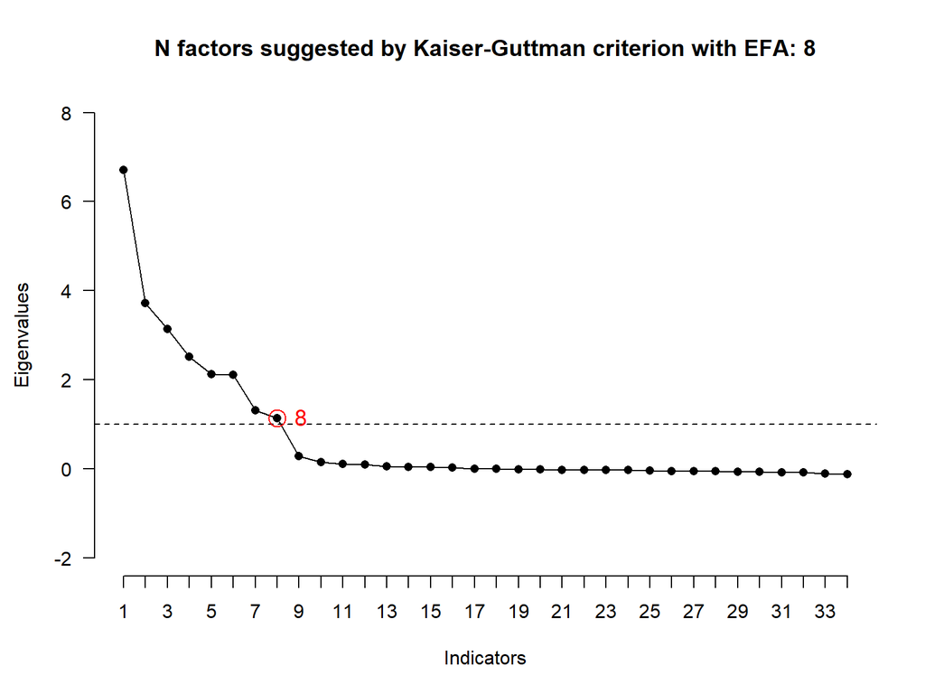

Factor Analysis using method = pa Call: fa(r = df_Cor2, nfactors = 8, rotate = “promax”, fm = “pa”) Standardized loadings (pattern matrix) based upon correlation matrix PA3 PA2 PA1 PA5 PA4 PA6 PA7 PA8 h2 u2 com SUPPORT1 0.01 -0.01 0.01 0.00 0.72 -0.02 0.04 0.01 0.53 0.47 1 SUPPORT2 0.02 0.01 0.01 -0.02 0.81 0.01 0.03 0.01 0.67 0.33 1 SUPPORT3 -0.02 -0.01 0.00 0.00 0.86 0.00 -0.06 0.00 0.73 0.27 1 SUPPORT4 -0.02 0.01 -0.01 0.01 0.82 0.00 -0.02 -0.01 0.67 0.33 1 WORRY1 -0.05 0.00 -0.01 0.00 -0.01 0.79 -0.06 0.01 0.64 0.36 1 WORRY2 -0.01 -0.04 -0.02 -0.01 -0.02 0.73 -0.01 0.02 0.55 0.45 1 WORRY3 0.03 0.03 -0.01 0.01 0.03 0.75 0.05 -0.04 0.54 0.46 1 WORRY4 0.03 0.00 0.03 0.00 0.00 0.72 0.02 0.02 0.52 0.48 1 AMBI1 -0.04 -0.02 -0.01 0.01 -0.04 0.03 0.88 0.02 0.75 0.25 1 AMBI2 0.01 0.00 0.01 0.02 0.05 0.02 0.72 -0.01 0.54 0.46 1 AMBI5 0.02 0.01 -0.01 -0.02 -0.02 -0.04 0.70 -0.01 0.50 0.50 1 BELONG1 0.00 0.78 0.02 -0.01 -0.01 0.00 -0.02 0.01 0.60 0.40 1 BELONG2 0.01 -0.81 -0.02 0.03 0.01 -0.02 -0.02 -0.03 0.64 0.36 1 BELONG3 -0.02 -0.69 0.02 -0.05 0.01 0.02 -0.03 0.03 0.51 0.49 1 BELONG4 -0.01 0.80 -0.01 0.00 0.03 -0.01 -0.02 0.00 0.65 0.35 1 BELONG5 0.00 -0.77 -0.01 0.00 0.00 -0.03 -0.01 0.00 0.59 0.41 1 BELONG6 0.00 0.85 -0.02 -0.02 -0.01 -0.01 -0.03 0.00 0.71 0.29 1 TEABUL5 -0.01 0.00 -0.03 0.00 0.01 -0.01 0.01 0.81 0.65 0.35 1 TEABUL6 0.01 0.01 0.02 0.00 -0.01 0.00 -0.01 0.82 0.67 0.33 1 DISORD1 0.00 0.01 0.00 0.74 0.00 0.01 -0.01 0.00 0.55 0.45 1 DISORD2 -0.01 0.01 0.04 0.86 0.00 0.01 0.02 0.03 0.71 0.29 1 DISORD3 -0.01 0.00 0.05 0.84 -0.01 -0.02 0.02 0.02 0.67 0.33 1 DISORD4 0.00 0.00 -0.05 0.76 -0.01 -0.01 -0.02 -0.01 0.62 0.38 1 DISORD5 0.02 -0.02 -0.04 0.77 0.02 0.00 -0.01 -0.03 0.64 0.36 1 TEASUP1 0.01 0.00 0.83 0.01 0.00 0.00 -0.02 0.00 0.68 0.32 1 TEASUP2 0.02 0.00 0.88 0.01 0.01 0.02 -0.01 0.00 0.77 0.23 1 TEASUP3 0.02 0.00 0.90 0.00 0.02 0.00 -0.01 0.01 0.81 0.19 1 TEASUP4 -0.03 0.01 0.84 -0.01 -0.01 0.00 0.01 0.00 0.71 0.29 1 TEASUP5 -0.02 0.00 0.82 -0.01 -0.02 -0.02 0.02 -0.02 0.67 0.33 1 LIKESCI1 -0.91 0.00 0.01 -0.01 -0.01 0.00 0.00 0.01 0.85 0.15 1 LIKESCI2 0.95 0.00 0.01 0.00 0.00 0.00 -0.01 -0.01 0.90 0.10 1 LIKESCI3 0.91 0.00 -0.01 -0.01 -0.01 -0.01 -0.03 0.02 0.81 0.19 1 LIKESCI4 0.92 0.00 0.01 0.00 -0.01 0.00 0.02 -0.01 0.85 0.15 1 LIKESCI5 0.94 0.00 0.01 0.00 0.00 0.01 0.01 0.01 0.88 0.12 1

```
                   PA3  PA2  PA1  PA5  PA4  PA6  PA7  PA8
```

SS loadings 4.30 3.68 3.66 3.17 2.60 2.24 1.79 1.33 Proportion Var 0.13 0.11 0.11 0.09 0.08 0.07 0.05 0.04 Cumulative Var 0.13 0.23 0.34 0.44 0.51 0.58 0.63 0.67 Proportion Explained 0.19 0.16 0.16 0.14 0.11 0.10 0.08 0.06 Cumulative Proportion 0.19 0.35 0.51 0.65 0.76 0.86 0.94 1.00

With factor correlations of PA3 PA2 PA1 PA5 PA4 PA6 PA7 PA8 PA3 1.00 0.05 -0.30 0.22 0.10 -0.16 0.31 -0.17 PA2 0.05 1.00 -0.13 0.13 0.12 -0.11 0.10 -0.11 PA1 -0.30 -0.13 1.00 -0.36 -0.18 0.18 -0.07 0.29 PA5 0.22 0.13 -0.36 1.00 0.11 -0.16 0.01 -0.25 PA4 0.10 0.12 -0.18 0.11 1.00 -0.10 0.21 -0.12 PA6 -0.16 -0.11 0.18 -0.16 -0.10 1.00 0.06 0.14 PA7 0.31 0.10 -0.07 0.01 0.21 0.06 1.00 -0.05 PA8 -0.17 -0.11 0.29 -0.25 -0.12 0.14 -0.05 1.00

Mean item complexity = 1 Test of the hypothesis that 8 factors are sufficient.

df null model = 561 with the objective function = 22.9 df of the model are 317 and the objective function was 0.68

The root mean square of the residuals (RMSR) is 0.01 The df corrected root mean square of the residuals is 0.02

Fit based upon off diagonal values = 1 Measures of factor score adequacy  
PA3 PA2 PA1 PA5 PA4 PA6 Correlation of (regression) scores with factors 0.98 0.95 0.97 0.95 0.94 0.92 Multiple R square of scores with factors 0.97 0.91 0.94 0.90 0.89 0.84 Minimum correlation of possible factor scores 0.94 0.82 0.87 0.80 0.78 0.68 PA7 PA8 Correlation of (regression) scores with factors 0.92 0.90 Multiple R square of scores with factors 0.84 0.80 Minimum correlation of possible factor scores 0.69 0.61

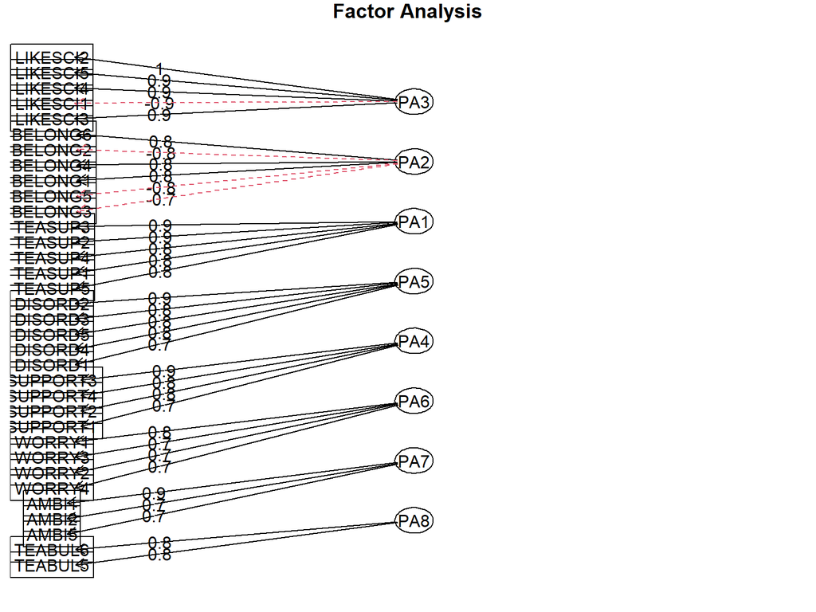

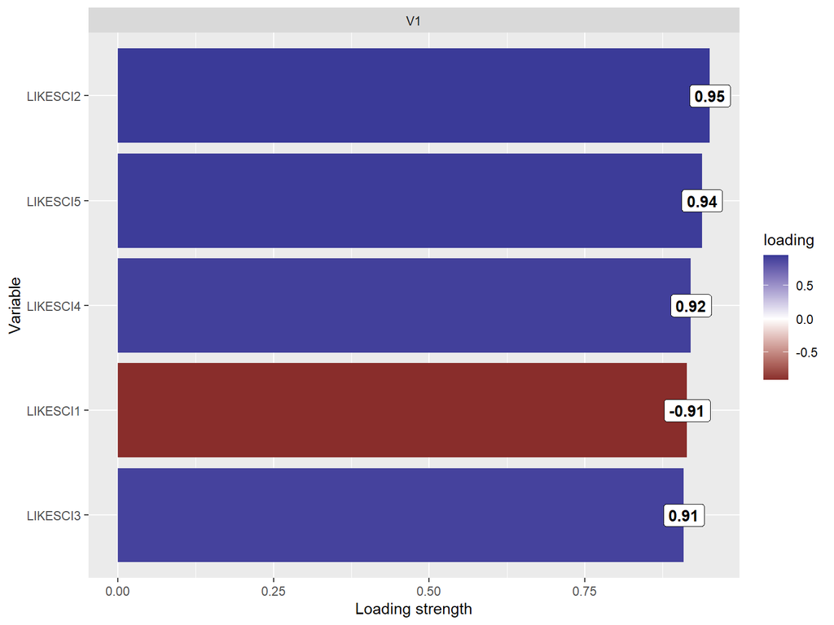

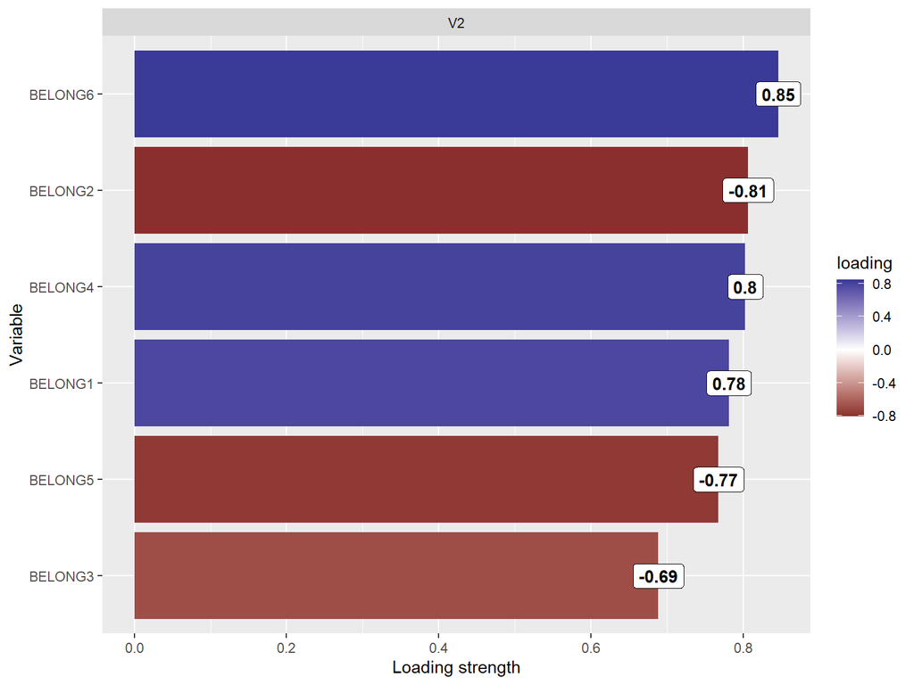

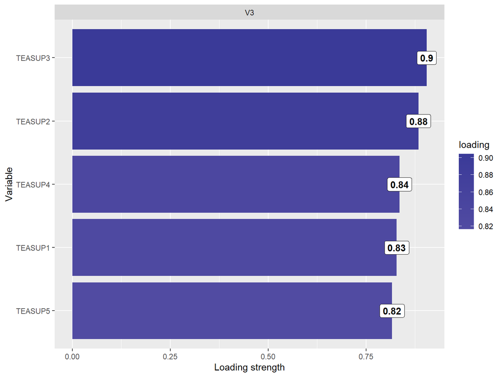

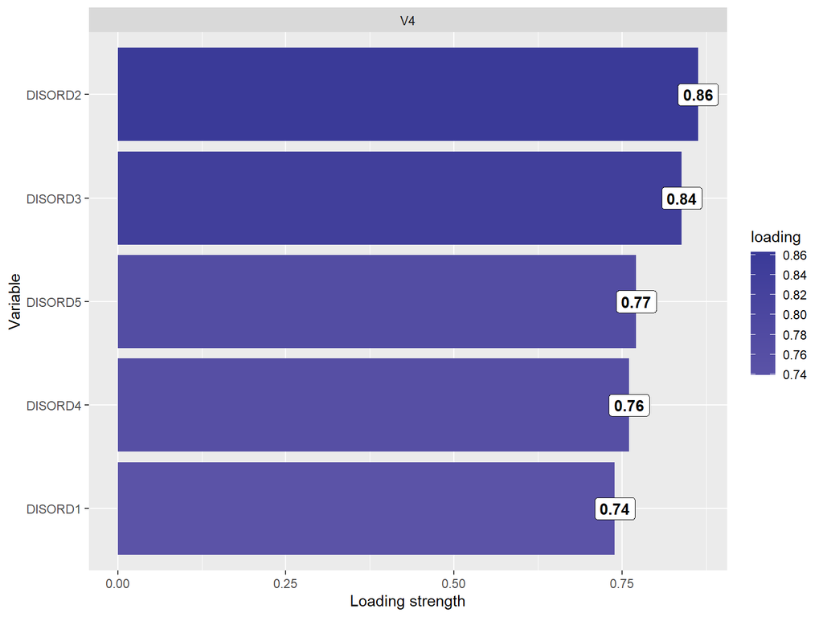

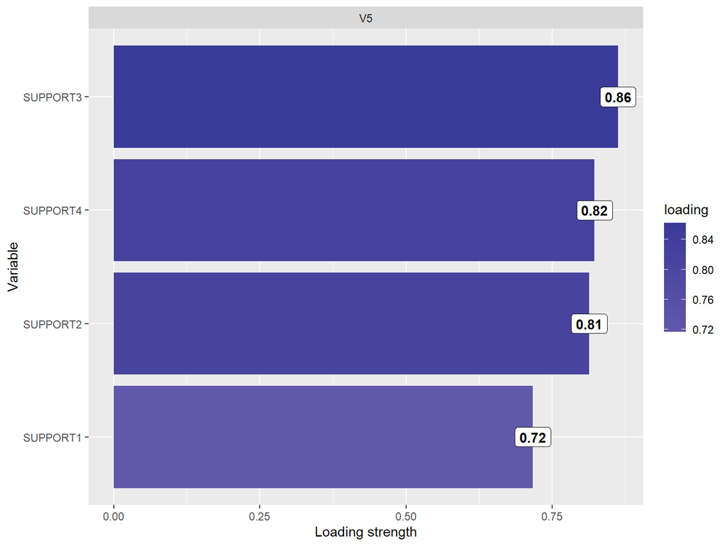

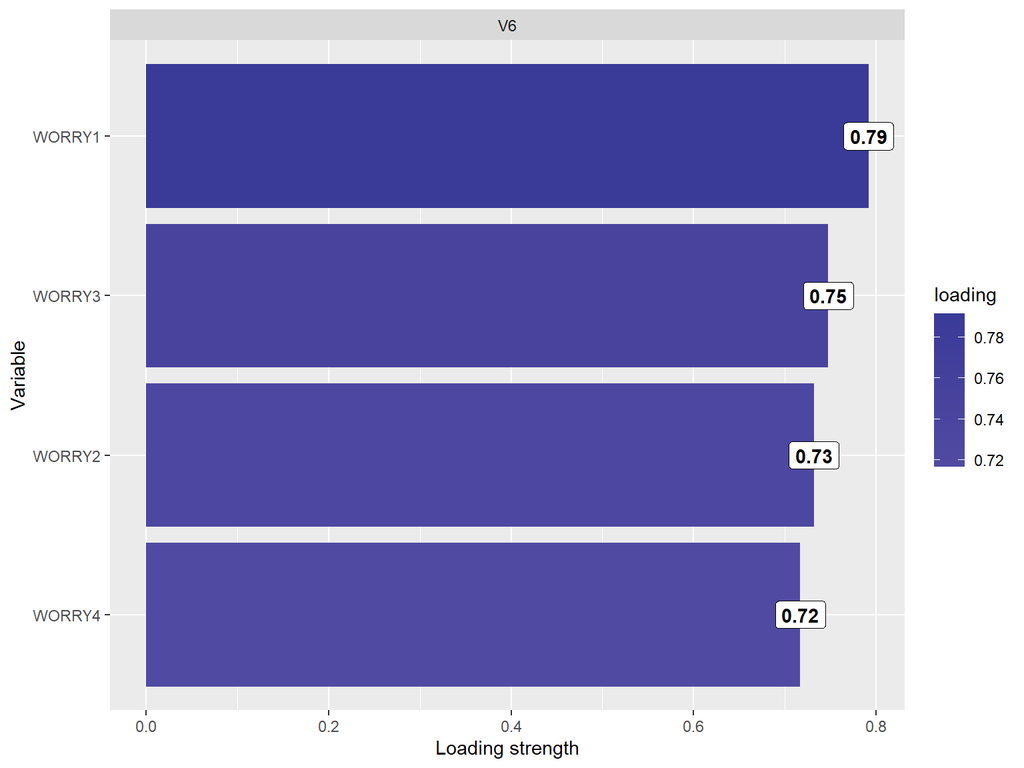

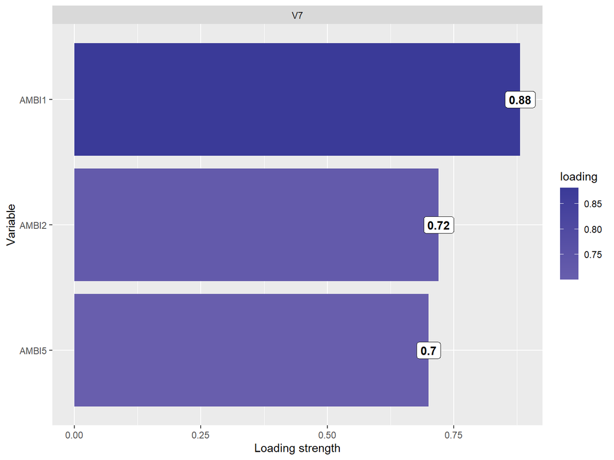

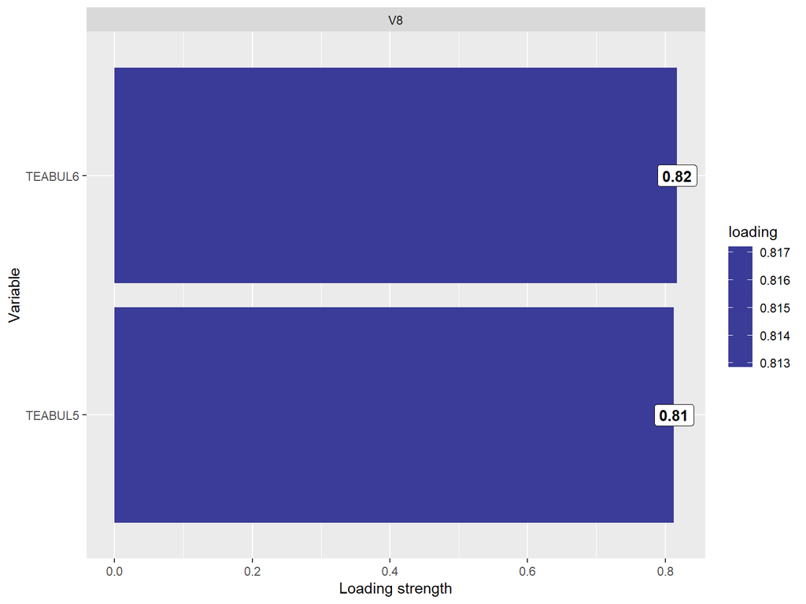

##### Post extraction communality

LIKESCI2(I like reading about science topic) and LIKESCI2(I’m Interested in Learning about Science) had the highest post extraction community percentage of 90%.while the lowest score was 50%AMB15(I want to be the best in class).

post Extration Communality Table

|  | sort(EFA_mod3$communality, decreasing = TRUE) |
| --- | --- |
| LIKESCI2 | 0.90 |
| LIKESCI5 | 0.88 |
| LIKESCI1 | 0.85 |
| LIKESCI4 | 0.85 |
| TEASUP3 | 0.81 |
| LIKESCI3 | 0.81 |
| TEASUP2 | 0.77 |
| AMBI1 | 0.75 |
| SUPPORT3 | 0.73 |
| TEASUP4 | 0.71 |
| BELONG6 | 0.71 |
| DISORD2 | 0.71 |
| TEASUP1 | 0.68 |
| TEABUL6 | 0.67 |
| SUPPORT4 | 0.67 |
| DISORD3 | 0.67 |
| SUPPORT2 | 0.67 |
| TEASUP5 | 0.67 |
| BELONG4 | 0.65 |
| TEABUL5 | 0.65 |
| WORRY1 | 0.64 |
| BELONG2 | 0.64 |
| DISORD5 | 0.64 |
| DISORD4 | 0.62 |
| BELONG1 | 0.60 |
| BELONG5 | 0.59 |
| WORRY2 | 0.55 |
| DISORD1 | 0.55 |
| WORRY3 | 0.54 |
| AMBI2 | 0.54 |
| SUPPORT1 | 0.53 |
| WORRY4 | 0.52 |
| BELONG3 | 0.51 |
| AMBI5 | 0.50 |

[1] 0.6696699

## REGRESSION ANALYSIS

|  | Female | Male | Overall |
| --- | --- | --- | --- |
|  | (N=1469) | (N=1315) | (N=2784) |
| BOOKS |  |  |  |
| Mean (SD) | 3.61 (1.42) | 3.36 (1.43) | 3.49 (1.43) |
| Median [Min, Max] | 3.00 [1.00, 6.00] | 3.00 [1.00, 6.00] | 3.00 [1.00, 6.00] |
| MATHSCORE |  |  |  |
| Mean (SD) | 505 (78.5) | 515 (84.0) | 510 (81.3) |
| Median [Min, Max] | 508 [238, 771] | 516 [202, 764] | 511 [202, 771] |
| BELONG |  |  |  |
| Mean (SD) | -0.0747 (0.983) | 0.111 (1.01) | 0.0131 (1.00) |
| Median [Min, Max] | 0.122 [-1.93, 1.50] | 0.338 [-1.93, 1.50] | 0.205 [-1.93, 1.50] |
| LIKES |  |  |  |
| Mean (SD) | -0.0367 (0.911) | 0.0320 (1.10) | -0.00423 (1.01) |
| Median [Min, Max] | 0.105 [-2.80, 1.32] | 0.367 [-2.81, 1.32] | 0.191 [-2.81, 1.32] |
| TEASUPPORT |  |  |  |
| Mean (SD) | 0.0726 (1.01) | -0.0747 (0.979) | 0.00304 (0.999) |
| Median [Min, Max] | -0.0193 [-1.12, 2.74] | -0.234 [-1.13, 2.75] | -0.0811 [-1.13, 2.75] |
| DISCORD |  |  |  |
| Mean (SD) | 0.305 (0.928) | -0.315 (0.969) | 0.0123 (0.997) |
| Median [Min, Max] | 0.303 [-2.20, 2.09] | -0.385 [-2.24, 2.06] | 0.000674 [-2.24, 2.09] |
| WORRY |  |  |  |
| Mean (SD) | -0.0841 (1.01) | 0.0521 (1.01) | -0.0198 (1.01) |
| Median [Min, Max] | 0.111 [-2.83, 1.60] | 0.147 [-2.82, 1.61] | 0.126 [-2.83, 1.61] |
| PARENTSP |  |  |  |
| Mean (SD) | 0.0357 (0.968) | -0.0312 (1.05) | 0.00409 (1.01) |
| Median [Min, Max] | 0.401 [-4.31, 0.897] | 0.312 [-4.40, 0.894] | 0.346 [-4.40, 0.897] |
| TEABUL |  |  |  |
| Mean (SD) | 0.0682 (0.956) | -0.0914 (1.03) | -0.00720 (0.994) |
| Median [Min, Max] | 0.118 [-3.46, 1.34] | -0.0429 [-3.52, 1.32] | 0.0677 [-3.52, 1.34] |
| AMBITIONS |  |  |  |
| Mean (SD) | -0.0567 (0.905) | 0.0518 (1.06) | -0.00548 (0.985) |
| Median [Min, Max] | -0.491 [-0.665, 4.34] | -0.497 [-0.694, 4.30] | -0.494 [-0.694, 4.34] |

### Visualise

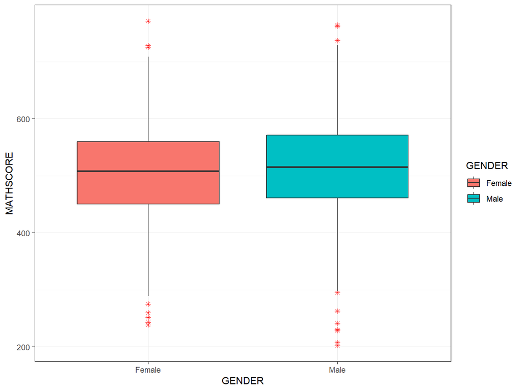

#Dependant variable The data is normally distributed

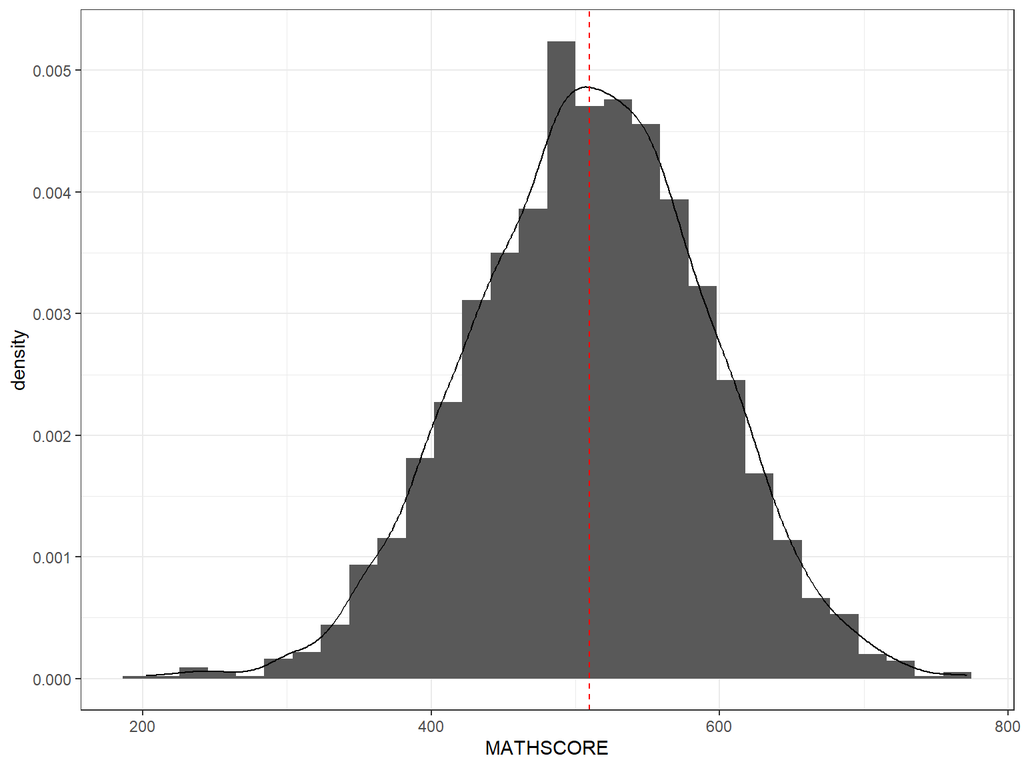

#### observe the coeficients

ANOVA Between Intercept Only and Random Intercept Model

| call | Model | df | AIC | BIC | logLik | Test | L.Ratio | p-value |
| --- | --- | --- | --- | --- | --- | --- | --- | --- |
| Intercept Only | 1 | 2 | 46271.86 | 46284.44 | -23133.93 |  | NA | NA |
| Random Intercept | 2 | 3 | 45997.58 | 46016.44 | -22995.79 | 1 vs 2 | 276.2827 | 0 |

[1] 0.136084

|  | Estimate | Std. Error | Pr(>\|t\|) | Star |
| --- | --- | --- | --- | --- |
| (Intercept) | 458.2107236 | 3.7071462 | 0.0000000 | *** |
| BOOKS | 14.3496884 | 0.7959913 | 0.0000000 | *** |
| LIKES | 5.7091521 | 1.1048645 | 0.0000002 | *** |
| GENDERMale | 3.7468139 | 2.3154988 | 0.1057128 |  |
| BELONG | 14.9005238 | 1.2340273 | 0.0000000 | *** |
| TEASUPPORT | 4.1392382 | 1.2650904 | 0.0010775 | ** |
| AMBITIONS | -9.2452474 | 1.1687214 | 0.0000000 | *** |
| PARENTSP | -4.2160446 | 1.1359218 | 0.0002089 | *** |
| WORRY | -0.8477181 | 1.2338674 | 0.4920968 |  |
| TEABUL | 11.2236013 | 1.1794255 | 0.0000000 | *** |
| DISCORD | -14.2329040 | 1.1899859 | 0.0000000 | *** |